# TP noté Modèle Linéaire

Saâd Qriouet 20171683

11/9/2020

# 1. Chargement des données et des différentes librairies

```r
library(MASS)
library(lasso2)
data <- data(Prostate)
names(Prostate)
```

```
## [1] "lcavol"  "lweight" "age"     "lbph"    "svi"     "lcp"     "gleason"
## [8] "pgg45"   "lpsa"
```

```r
dim(Prostate)
```

```
## [1] 97  9
```

```r
names(Prostate)
```

```
## [1] "lcavol"  "lweight" "age"     "lbph"    "svi"     "lcp"     "gleason"
## [8] "pgg45"   "lpsa"
```

# 2. Transformation des variables

```r
Prostate$svi <- as.factor(Prostate$svi)
Prostate$gleason <- as.factor(Prostate$gleason)
summary(Prostate)
```

```
##      lcavol           lweight           age             lbph         svi
##  Min.   :-1.3471   Min.   :2.375   Min.   :41.00   Min.   :-1.3863   0:76
##  1st Qu.: 0.5128   1st Qu.:3.376   1st Qu.:60.00   1st Qu.:-1.3863   1:21
##  Median : 1.4469   Median :3.623   Median :65.00   Median : 0.3001
##  Mean   : 1.3500   Mean   :3.653   Mean   :63.87   Mean   : 0.1004
##  3rd Qu.: 2.1270   3rd Qu.:3.878   3rd Qu.:68.00   3rd Qu.: 1.5581
##  Max.   : 3.8210   Max.   :6.108   Max.   :79.00   Max.   : 2.3263
##       lcp          gleason     pgg45             lpsa
##  Min.   :-1.3863   6:35    Min.   :  0.00   Min.   :-0.4308
##  1st Qu.:-1.3863   7:56    1st Qu.:  0.00   1st Qu.: 1.7317
##  Median :-0.7985   8: 1    Median : 15.00   Median : 2.5915
##  Mean   :-0.1794   9: 5    Mean   : 24.38   Mean   : 2.4784
##  3rd Qu.: 1.1787           3rd Qu.: 40.00   3rd Qu.: 3.0564
##  Max.   : 2.9042           Max.   :100.00   Max.   : 5.5829
```

# Nous allons réaliser un scatterplot des variables :

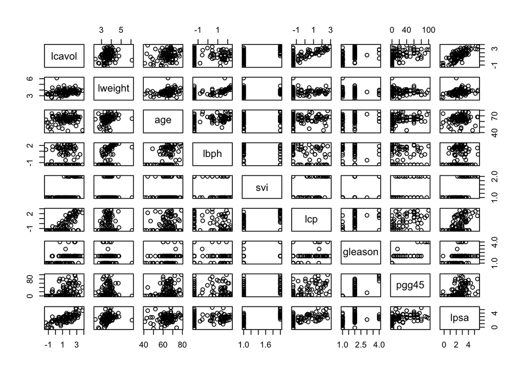

```r
pairs(Prostate)
```

# 3. Modèle de régression linéaire simple expliquant lpsa en fonction de lcavol

On utilise la fonction lm() afin de mettre en oeuvre un modèle linéaire :

```r
mod1 = lm(lpsa~lcavol, data = Prostate)
summary(mod1)
```

```
##
## Call:
## lm(formula = lpsa ~ lcavol, data = Prostate)
##
## Residuals:
##      Min       1Q   Median       3Q      Max
## -1.67624 -0.41648  0.09859  0.50709  1.89672
##
## Coefficients:
##             Estimate Std. Error t value Pr(>|t|)
## (Intercept)  1.50730    0.12194   12.36   <2e-16 ***
## lcavol       0.71932    0.06819   10.55   <2e-16 ***
## ---
## Signif. codes:  0 '***' 0.001 '**' 0.01 '*' 0.05 '.' 0.1 ' ' 1
##
## Residual standard error: 0.7875 on 95 degrees of freedom
## Multiple R-squared:  0.5394, Adjusted R-squared:  0.5346
## F-statistic: 111.3 on 1 and 95 DF,  p-value: < 2.2e-16
```

# 3.(f)

Une estimation de l’équation de la droite des moindres carrées associée au problème est donc : y = 1.50730 + 0.71932*x, où x correspond à la valeur de lcavol et y une prévision de lpsa. Nous pouvons recuperer les coefficients à partir du summary(mod1) en les lisant dans le tableau, ou en les extrayant comme suit :

```r
a = mod1$coefficients[1]
b = mod1$coefficients[2]
```

# 3.(g)

Pour réaliser la prédiction, on utilise la fonction predict() :

```r
print("La prédiction avec la predict() est égale à : ")
```

```
## [1] "La prédiction avec la predict() est égale à : "
```

```r
newdata = data.frame(lcavol = 1.35)
pred = predict(mod1, newdata)
print(pred)
```

```
##       1
## 2.47838
```

En remplacant “pred = predict(mod1, newdata)” par “pred = predict(mod1, newdata, interval =”predict“)”, on obtient aussi l’intervalle de prédiction de la prédiction.

# 3.(j)

Nous allons comparer le modèle mod0 (contenant uniquement l’intercept) et le modèle m1 (contenant l’intercept et la variable lcavol) grâce a la fonction anova() :

```r
mod0 = lm(lpsa~1, data = Prostate)
anova(mod0,mod1)
```

```
## Analysis of Variance Table
##
## Model 1: lpsa ~ 1
## Model 2: lpsa ~ lcavol
##   Res.Df     RSS Df Sum of Sq      F    Pr(>F)
## 1     96 127.918
## 2     95  58.915  1    69.003 111.27 < 2.2e-16 ***
## ---
## Signif. codes:  0 '***' 0.001 '**' 0.01 '*' 0.05 '.' 0.1 ' ' 1
```

# 3.(k)

Nous allons analyser le plot des residus en fonction des valeurs prédites, et le QQ-plot grâce à la fonction plot() appliquée à mod1 :

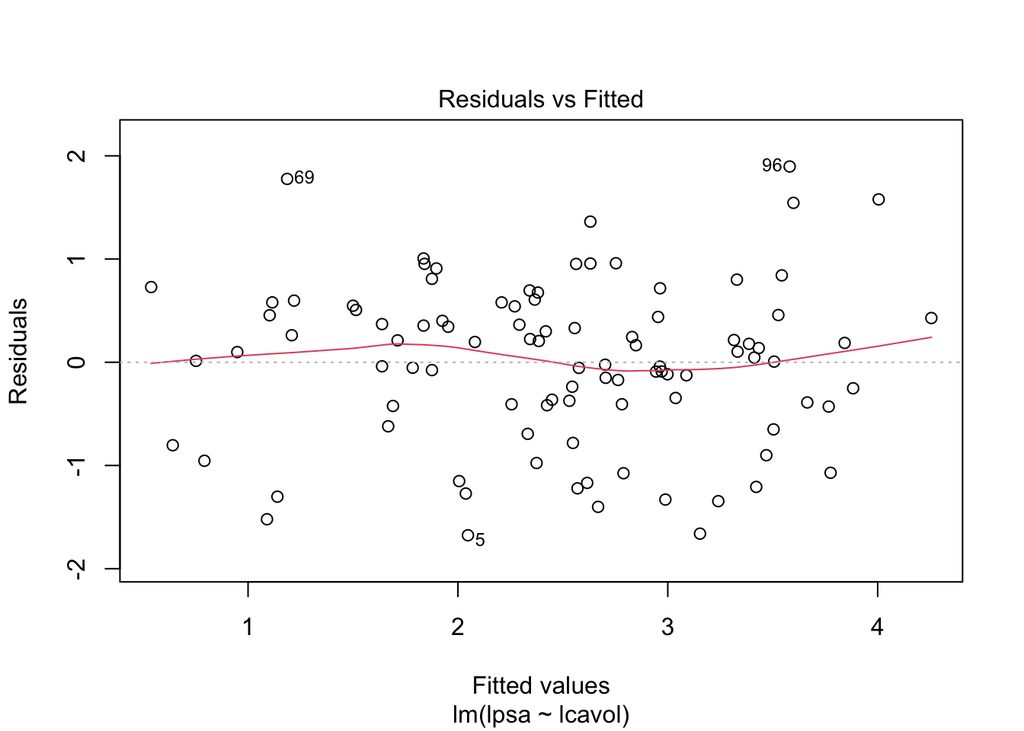

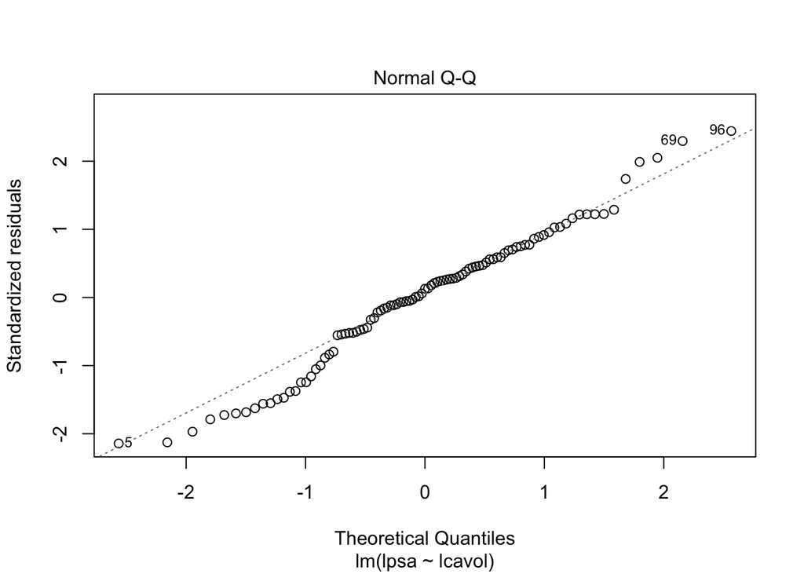

```r
plot(mod1,which=1:2)
```

# 4. Modèle complet

```r
mod2 = lm(lpsa~. , data = Prostate )
summary(mod2)
```

```
##
## Call:
## lm(formula = lpsa ~ ., data = Prostate)
##
## Residuals:
##      Min       1Q   Median       3Q      Max
## -1.74817 -0.35037 -0.02626  0.47654  1.70256
##
## Coefficients:
##              Estimate Std. Error t value Pr(>|t|)
## (Intercept)  0.913313   0.840836   1.086  0.28043
## lcavol       0.569989   0.090100   6.326 1.09e-08 ***
## lweight      0.468783   0.169610   2.764  0.00699 **
## age         -0.021749   0.011361  -1.914  0.05890 .
## lbph         0.099685   0.058984   1.690  0.09464 .
## svi1         0.745877   0.247398   3.015  0.00338 **
## lcp         -0.125111   0.095591  -1.309  0.19408
## gleason7     0.267601   0.219419   1.220  0.22596
## gleason8     0.496798   0.769268   0.646  0.52012
## gleason9    -0.056230   0.500196  -0.112  0.91076
## pgg45        0.004990   0.004672   1.068  0.28847
## ---
## Signif. codes:  0 '***' 0.001 '**' 0.01 '*' 0.05 '.' 0.1 ' ' 1
##
## Residual standard error: 0.7048 on 86 degrees of freedom
## Multiple R-squared:  0.666,  Adjusted R-squared:  0.6272
## F-statistic: 17.15 on 10 and 86 DF,  p-value: < 2.2e-16
```

# 5. Comparaison de modèles emboités

```r
mod0 = lm(lpsa~1 , data = Prostate )
modA = lm(lpsa ~ lcavol+pgg45, data = Prostate)
modB = lm(lpsa ~ lcavol+lweight, data = Prostate)
modC = lm(lpsa ~ lcavol+lweight+age , data = Prostate)
anova(modA,modB)
```

```
## Analysis of Variance Table
##
## Model 1: lpsa ~ lcavol + pgg45
## Model 2: lpsa ~ lcavol + lweight
##   Res.Df    RSS Df Sum of Sq F Pr(>F)
## 1     94 57.217
## 2     94 52.966  0    4.2505
```

Le degré de liberté de ce test de comparaison est nul, nous ne pouvons donc pas calculer la p-value. Nous allons donc proceder d’une autre manière afin de comparer ces deux modèles (plus tard dans le TP)

```r
anova(modA,modC)
```

```
## Analysis of Variance Table
##
## Model 1: lpsa ~ lcavol + pgg45
## Model 2: lpsa ~ lcavol + lweight + age
##   Res.Df    RSS Df Sum of Sq      F   Pr(>F)
## 1     94 57.217
## 2     93 52.546  1    4.6705 8.2661 0.005007 **
## ---
## Signif. codes:  0 '***' 0.001 '**' 0.01 '*' 0.05 '.' 0.1 ' ' 1
```

p-value < 0.01, donc on rejette le premier modèle par rapport au 3ème à 5% et 1%

```r
anova(modB,modC)
```

```
## Analysis of Variance Table
##
## Model 1: lpsa ~ lcavol + lweight
## Model 2: lpsa ~ lcavol + lweight + age
##   Res.Df    RSS Df Sum of Sq      F Pr(>F)
## 1     94 52.966
## 2     93 52.546  1   0.41999 0.7433 0.3908
```

p-value ~= 0.39, donc on ne rejette pas le second modèle par rapport au 3ème

Pour comparer les deux premiers modèles, nous allons d’abord calculer l’erreur de prédiction des deux modèles :

```r
res_modA = residuals(modA)
mean(res_modA**2)
```

```
## [1] 0.5898642
```

```r
res_modB = residuals(modB)
mean(res_modB**2)
```

```
## [1] 0.5460449
```

Le second modèle à l’erreur de prédiction la plus petite, donc à une meilleure estimation. Cependant la différence est trop faible pour pouvoir conclure dessus.

Nous allons calculer les différents AIC des variables concernées grace aux algorithmes suivants :

AIC “forward” :

```r
modselect_f = stepAIC(mod1, lpsa~lcavol+lweight+pgg45, trace=TRUE, direction=c("forward"))
```

```
## Start:  AIC=-44.37
## lpsa ~ lcavol
##
##           Df Sum of Sq    RSS     AIC
## + lweight  1    5.9484 52.966 -52.690
## + pgg45    1    1.6980 57.217 -45.203
## <none>                 58.915 -44.366
##
## Step:  AIC=-52.69
## lpsa ~ lcavol + lweight
##
##         Df Sum of Sq    RSS     AIC
## + pgg45  1    1.9489 51.017 -54.327
## <none>               52.966 -52.690
##
## Step:  AIC=-54.33
## lpsa ~ lcavol + lweight + pgg45
```

```r
summary(modselect_f)
```

```
##
## Call:
## lm(formula = lpsa ~ lcavol + lweight + pgg45, data = Prostate)
##
## Residuals:
##      Min       1Q   Median       3Q      Max
## -1.48486 -0.45150  0.01279  0.47778  1.91619
##
## Coefficients:
##              Estimate Std. Error t value Pr(>|t|)
## (Intercept) -0.399890   0.563835  -0.709  0.47995
## lcavol       0.618403   0.072516   8.528 2.65e-13 ***
## lweight      0.521982   0.155274   3.362  0.00113 **
## pgg45        0.005610   0.002977   1.885  0.06257 .
## ---
## Signif. codes:  0 '***' 0.001 '**' 0.01 '*' 0.05 '.' 0.1 ' ' 1
##
## Residual standard error: 0.7407 on 93 degrees of freedom
## Multiple R-squared:  0.6012, Adjusted R-squared:  0.5883
## F-statistic: 46.73 on 3 and 93 DF,  p-value: < 2.2e-16
```

La variable lweight à été ajoutée au modèle avant pgg45, donc le second modèle est meillleur que le premier selon l’algo “forward”.

AIC “backward” :

```r
modselect_b = stepAIC(mod2, ~., trace=TRUE, direction=c("backward"))
```

```
## Start:  AIC=-57.54
## lpsa ~ lcavol + lweight + age + lbph + svi + lcp + gleason +
##     pgg45
##
##           Df Sum of Sq    RSS     AIC
## - gleason  3    1.4804 44.204 -60.231
## - pgg45    1    0.5667 43.291 -58.257
## - lcp      1    0.8510 43.575 -57.622
## <none>                 42.724 -57.535
## - lbph     1    1.4190 44.143 -56.366
## - age      1    1.8206 44.545 -55.487
## - lweight  1    3.7950 46.519 -51.281
## - svi      1    4.5156 47.240 -49.790
## - lcavol   1   19.8819 62.606 -22.472
##
## Step:  AIC=-60.23
## lpsa ~ lcavol + lweight + age + lbph + svi + lcp + pgg45
##
##           Df Sum of Sq    RSS     AIC
## - lcp      1    0.6623 44.867 -60.788
## <none>                 44.204 -60.231
## - pgg45    1    1.1920 45.396 -59.650
## - age      1    1.5166 45.721 -58.959
## - lbph     1    1.7053 45.910 -58.559
## - lweight  1    3.5461 47.751 -54.746
## - svi      1    4.8984 49.103 -52.037
## - lcavol   1   23.5039 67.708 -20.872
##
## Step:  AIC=-60.79
## lpsa ~ lcavol + lweight + age + lbph + svi + pgg45
##
##           Df Sum of Sq    RSS     AIC
## - pgg45    1    0.6590 45.526 -61.374
## <none>                 44.867 -60.788
## - age      1    1.2649 46.132 -60.092
## - lbph     1    1.6465 46.513 -59.293
## - lweight  1    3.5646 48.431 -55.373
## - svi      1    4.2503 49.117 -54.009
## - lcavol   1   25.4190 70.286 -19.248
##
## Step:  AIC=-61.37
## lpsa ~ lcavol + lweight + age + lbph + svi
##
##           Df Sum of Sq    RSS     AIC
## <none>                 45.526 -61.374
## - age      1    0.9593 46.485 -61.352
## - lbph     1    1.8568 47.382 -59.497
## - lweight  1    3.2250 48.751 -56.735
## - svi      1    5.9517 51.477 -51.456
## - lcavol   1   28.7666 74.292 -15.870
```

```r
summary(modselect_b)
```

```
##
## Call:
## lm(formula = lpsa ~ lcavol + lweight + age + lbph + svi, data = Prostate)
##
## Residuals:
##      Min       1Q   Median       3Q      Max
## -1.83506 -0.39395  0.00412  0.46336  1.57887
##
## Coefficients:
##             Estimate Std. Error t value Pr(>|t|)
## (Intercept)  0.95102    0.83174   1.143 0.255870
## lcavol       0.56561    0.07459   7.583 2.77e-11 ***
## lweight      0.42369    0.16687   2.539 0.012815 *
## age         -0.01489    0.01075  -1.385 0.169527
## lbph         0.11184    0.05805   1.927 0.057160 .
## svi1         0.72096    0.20902   3.449 0.000854 ***
## ---
## Signif. codes:  0 '***' 0.001 '**' 0.01 '*' 0.05 '.' 0.1 ' ' 1
##
## Residual standard error: 0.7073 on 91 degrees of freedom
## Multiple R-squared:  0.6441, Adjusted R-squared:  0.6245
## F-statistic: 32.94 on 5 and 91 DF,  p-value: < 2.2e-16
```

La variable pgg45 à été retirée contrairement a lweight, le second modèle est donc meilleur que le premier modèle selon l’algo “backward”.

AIC “stepwise” :

```r
modselect_st = stepAIC(mod0, lpsa~lcavol+lweight+pgg45, trace=TRUE, direction=c("both"))
```

```
## Start:  AIC=28.84
## lpsa ~ 1
##
##           Df Sum of Sq     RSS     AIC
## + lcavol   1    69.003  58.915 -44.366
## + pgg45    1    22.814 105.103  11.783
## + lweight  1    16.041 111.877  17.841
## <none>                 127.918  28.838
##
## Step:  AIC=-44.37
## lpsa ~ lcavol
##
##           Df Sum of Sq     RSS     AIC
## + lweight  1     5.948  52.966 -52.690
## + pgg45    1     1.698  57.217 -45.203
## <none>                  58.915 -44.366
## - lcavol   1    69.003 127.918  28.838
##
## Step:  AIC=-52.69
## lpsa ~ lcavol + lweight
##
##           Df Sum of Sq     RSS     AIC
## + pgg45    1     1.949  51.017 -54.327
## <none>                  52.966 -52.690
## - lweight  1     5.948  58.915 -44.366
## - lcavol   1    58.910 111.877  17.841
##
## Step:  AIC=-54.33
## lpsa ~ lcavol + lweight + pgg45
##
##           Df Sum of Sq    RSS     AIC
## <none>                 51.017 -54.327
## - pgg45    1     1.949 52.966 -52.690
## - lweight  1     6.199 57.217 -45.203
## - lcavol   1    39.895 90.912  -0.287
```

```r
summary(modselect_st)
```

```
##
## Call:
## lm(formula = lpsa ~ lcavol + lweight + pgg45, data = Prostate)
##
## Residuals:
##      Min       1Q   Median       3Q      Max
## -1.48486 -0.45150  0.01279  0.47778  1.91619
##
## Coefficients:
##              Estimate Std. Error t value Pr(>|t|)
## (Intercept) -0.399890   0.563835  -0.709  0.47995
## lcavol       0.618403   0.072516   8.528 2.65e-13 ***
## lweight      0.521982   0.155274   3.362  0.00113 **
## pgg45        0.005610   0.002977   1.885  0.06257 .
## ---
## Signif. codes:  0 '***' 0.001 '**' 0.01 '*' 0.05 '.' 0.1 ' ' 1
##
## Residual standard error: 0.7407 on 93 degrees of freedom
## Multiple R-squared:  0.6012, Adjusted R-squared:  0.5883
## F-statistic: 46.73 on 3 and 93 DF,  p-value: < 2.2e-16
```